# Vector Autoregression Time Series with WSTS Analog and ADI Revenue

Hilary Lai

2021-09-16

## Objective

Find out relationships with WSTS analog semiconductor revenue and ADI revenue as well as make predictions.

## Method

Vector Autoregression Model (VAR):

Christopher Sims proposed the Vector Autoregression which is a multivariate linear time series model

## Data source:

- WSTS for analog semiconductor
- ADI revenue (labeled as “Revenue” in the model)
- OECD Unemployment rate

## 1. Preparing the dataset

```r
library(tidyverse)
library(readr)
library(janitor)
library(ggplot2)
library(ggfortify)
library(TTR)
library(forecast)
library(fable)
library(vars)
library(tseries)
library(MTS)

ana <- read_csv("Analog_Semi_WSTS.csv")
ana <- clean_names(ana[-c(1,2,4),-c(2,5,10,12,14)]) %>%
  row_to_names(1)
#calendar month
colnames(ana)[c(1,8,9)] <- c("CM", "GENERAL PURPOSE ANALOG","APPLICATION SPECIFIC ANALOG")
ana <- sapply(ana, as.numeric) %>%
  as.data.frame()

#get revenue
#exclude most recent values
dar <- read_csv("DAR_6yrs.csv") %>%
  .[-1,]
dar$Revenue <- gsub("[],\\)]", "",dar$Revenue)
dar$Revenue <- gsub("^\\(", "-",dar$Revenue)
dar$Revenue <- gsub("\\$", "",dar$Revenue) %>% as.numeric()

#get cal to join fiscal month
#join calendar to get fiscal qtr
cal <- read_csv("C:\\Users\\hlai\\Analog Devices, Inc\\APR-Data-Team - Power BI Development\\Project\\master_data\\Calendar_Week.csv") %>%
  .[-1,-6]

dar <- dar %>%
  left_join(cal[,c(1:2)]) %>%
  mutate(FM = ceiling(Fiscal_Wk%%100 * 1/52 * 12)+Fiscal_Wk%/%100*100) %>%
  dplyr::group_by(FM) %>%
  summarise(Revenue = sum(Revenue)) %>%
  filter(FM != max(FM)) %>%
  arrange(FM)

dar <- dar %>%
  mutate(Revenue = Revenue/1000,
         CM = ifelse(
           FM%%100 < 3, (FM%/%100 - 1) * 100 + (FM%%100+10),
           (FM%/%100) * 100 + (FM%%100-2)
         ))
dar <- dar[dar$FM!=201813,]

df <- ana %>%
  left_join(dar)%>%na.omit %>% as.data.frame()

lineplot <- df %>% .[,-10] %>%
  gather(Type, Value, AM:Revenue) %>%
  ggplot() +
  geom_line(aes(x=factor(CM), y=Value, color=Type, group=Type)) +
  xlab("Calendar Month")+
  theme(axis.text.x = element_text(angle = 90, vjust = 0.5, hjust=1, size=5))
```

## 2. Plotting all regions with ADI revenue

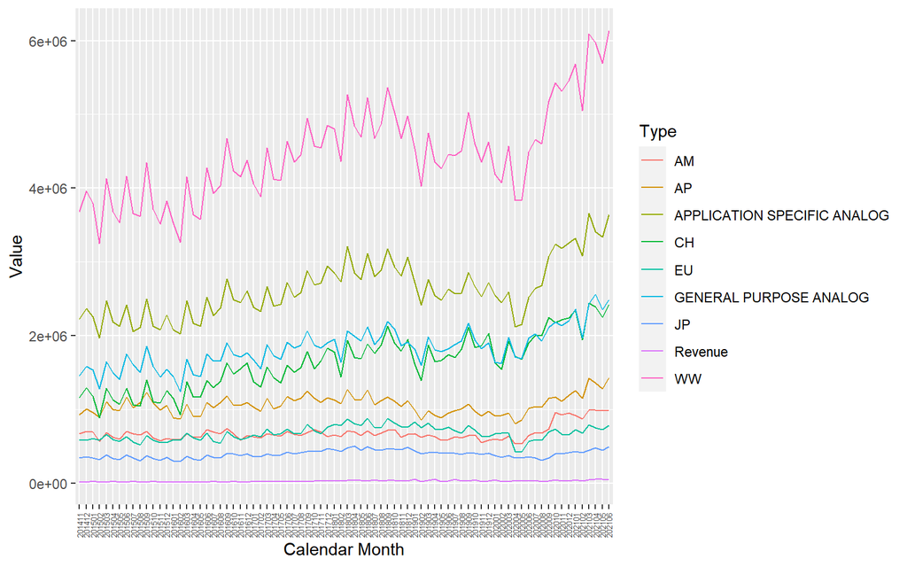

```r
lineplot
```

## 3. Univariate Time Series Model with only WW data

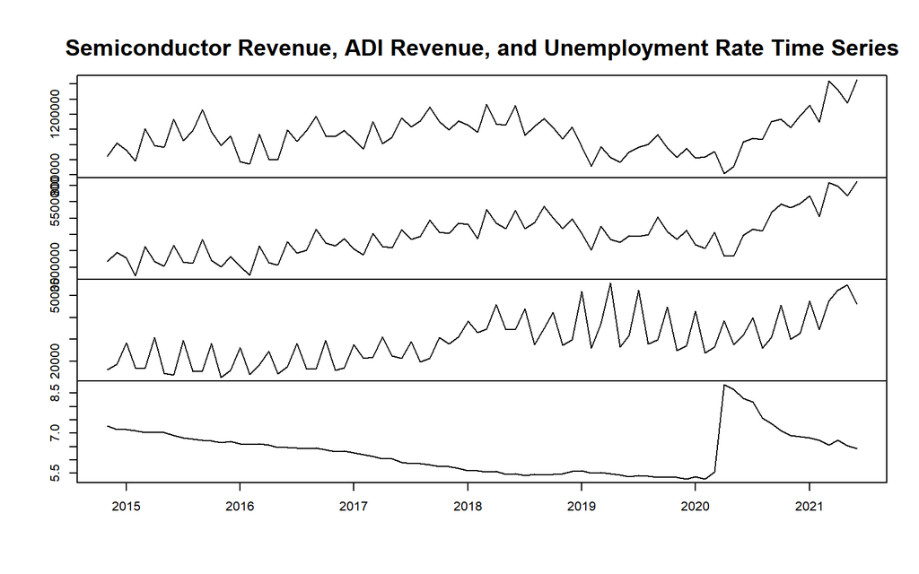

```r
library(knitr)
#read unemployment
em <- read_csv("Unemploy.csv")[,c(9,17)]
em <- em[-nrow(em),]
colnames(em)[2] <- "UnEmploy"

#adding unemployment rate to the model
df <- cbind(df, em[,2])

#time series analysis
ana.ts <- ts(df[,c(6,7,11,12)] %>% na.omit(), start = c(2014,11),frequency = 12)
plot(ana.ts, ann=FALSE); title(main = "Semiconductor Revenue, ADI Revenue, and Unemployment Rate Time Series")
```

```r
fitww <- auto.arima(ana.ts[,2])
fcww <- forecast(fitww, h=12)
```

Model Summary:

```r
summary(fitww)
```

```
## Series: ana.ts[, 2]
## ARIMA(2,0,0)(0,1,2)[12]
##
## Coefficients:
##          ar1     ar2     sma1    sma2
##       0.7601  0.2155  -1.0212  0.5146
## s.e.  0.1203  0.1217   0.2453  0.3567
##
## sigma^2 estimated as 3.659e+10:  log likelihood=-929.43
## AIC=1868.85   AICc=1869.82   BIC=1879.95
##
## Training set error measures:
##                    ME     RMSE      MAE       MPE     MAPE      MASE
## Training set 24269.03 171092.7 116511.8 0.4456872 2.525902 0.2358344
##                     ACF1
## Training set -0.01973527
```

Plotting forecast data:

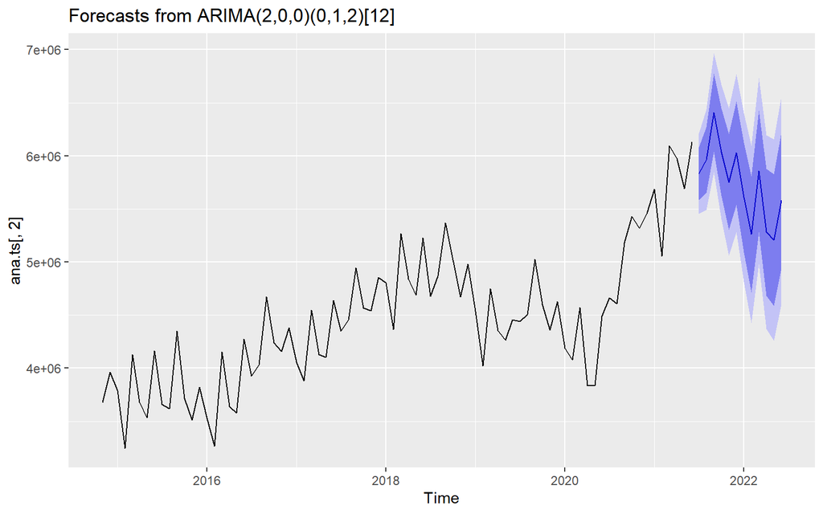

```r
autoplot(fcww)
```

Forecast for the next 12 months:

```r
kable(fcww)
```

|  | Point Forecast | Lo 80 | Hi 80 | Lo 95 | Hi 95 |
| --- | --- | --- | --- | --- | --- |
| Jul 2021 | 5832904 | 5586042 | 6079766 | 5455362 | 6210447 |
| Aug 2021 | 5963482 | 5653456 | 6273509 | 5489338 | 6437627 |
| Sep 2021 | 6408431 | 6041829 | 6775034 | 5847761 | 6969101 |
| Oct 2021 | 6036849 | 5624374 | 6449324 | 5406022 | 6667675 |
| Nov 2021 | 5753749 | 5301444 | 6206054 | 5062009 | 6445490 |
| Dec 2021 | 6027100 | 5539890 | 6514309 | 5281977 | 6772222 |
| Jan 2022 | 5608415 | 5089884 | 6126947 | 4815390 | 6401441 |
| Feb 2022 | 5260722 | 4713799 | 5807645 | 4424276 | 6097168 |
| Mar 2022 | 5856800 | 5283935 | 6429665 | 4980679 | 6732921 |
| Apr 2022 | 5280790 | 4684073 | 5877506 | 4368190 | 6193389 |
| May 2022 | 5207284 | 4588527 | 5826041 | 4260977 | 6153591 |
| Jun 2022 | 5581148 | 4941940 | 6220355 | 4603564 | 6558731 |

## 4. Multivariate Time Series Model with Vector Autoregression (VAR)

For this model, I will be only using **AP & WW Semi** data, and employing unemployment rate.

4-1. Selecting lag for the model

```r
VARselect(ana.ts, lag.max=8,
          type="const")[["selection"]]
```

```
## AIC(n)  HQ(n)  SC(n) FPE(n)
##      4      4      3      4
```

Staring with lag = 3, and try the serial test

```r
var1 <- vars::VAR(ana.ts, p=3, type="trend")
serial.test(var1, lags.pt=10, type="PT.asymptotic")
```

```
##
##  Portmanteau Test (asymptotic)
##
## data:  Residuals of VAR object var1
## Chi-squared = 149.48, df = 112, p-value = 0.01037
```

4-2. Serial test failed (p value < 0.05), try lag = 4 instead:

```r
var2 <- vars::VAR(ana.ts, p=4, type="trend")
serial.test(var2, lags.pt=10, type="PT.asymptotic")
```

```
##
##  Portmanteau Test (asymptotic)
##
## data:  Residuals of VAR object var2
## Chi-squared = 111.95, df = 96, p-value = 0.1271
```

Serial test succeeded, now I can use the second model and get the summary.

Model summary:

```r
modelsumm <- summary(var2)
modelsumm
```

```
##
## VAR Estimation Results:
## =========================
## Endogenous variables: AP, WW, Revenue, UnEmploy
## Deterministic variables: trend
## Sample size: 76
## Log Likelihood: -2657.205
## Roots of the characteristic polynomial:
## 0.9926 0.9771 0.9771 0.8658 0.8631 0.8631 0.8185 0.8185 0.737 0.737 0.7029 0.7029 0.5709 0.5709 0.3253 0.2461
## Call:
## vars::VAR(y = ana.ts, p = 4, type = "trend")
##
##
## Estimation results for equation AP:
## ===================================
## AP = AP.l1 + WW.l1 + Revenue.l1 + UnEmploy.l1 + AP.l2 + WW.l2 + Revenue.l2 + UnEmploy.l2 + AP.l3 + WW.l3 + Revenue.l3 + UnEmploy.l3 + AP.l4 + WW.l4 + Revenue.l4 + UnEmploy.l4 + trend
##
##               Estimate Std. Error t value Pr(>|t|)
## AP.l1        1.354e+00  2.467e-01   5.488 8.97e-07 ***
## WW.l1       -2.531e-01  6.927e-02  -3.653 0.000552 ***
## Revenue.l1   2.008e+00  1.692e+00   1.187 0.240104
## UnEmploy.l1  6.005e+02  1.897e+04   0.032 0.974853
## AP.l2       -2.860e-01  2.946e-01  -0.971 0.335568
## WW.l2        1.953e-01  7.856e-02   2.486 0.015790 *
## Revenue.l2   1.117e+00  1.262e+00   0.885 0.379814
## UnEmploy.l2  2.668e+03  2.753e+04   0.097 0.923128
## AP.l3       -2.639e-01  3.209e-01  -0.822 0.414154
## WW.l3        1.650e-01  8.042e-02   2.052 0.044632 *
## Revenue.l3   2.134e+00  1.377e+00   1.550 0.126520
## UnEmploy.l3  3.544e+04  2.695e+04   1.315 0.193612
## AP.l4       -2.964e-03  2.616e-01  -0.011 0.990997
## WW.l4       -9.782e-02  6.948e-02  -1.408 0.164419
## Revenue.l4  -4.596e+00  1.760e+00  -2.612 0.011400 *
## UnEmploy.l4 -1.322e+04  1.980e+04  -0.668 0.506850
## trend       -8.808e+01  1.053e+03  -0.084 0.933622
## ---
## Signif. codes:  0 '***' 0.001 '**' 0.01 '*' 0.05 '.' 0.1 ' ' 1
##
##
## Residual standard error: 56970 on 59 degrees of freedom
```

[output cut: 96 more lines]

```
##
##
## Covariance matrix of residuals:
##                  AP         WW    Revenue   UnEmploy
## AP        3.245e+09  1.081e+10  6.326e+07 -1.989e+03
## WW        1.081e+10  4.741e+10  2.253e+08 -1.335e+04
## Revenue   6.326e+07  2.253e+08  1.621e+07 -3.801e+02
## UnEmploy -1.989e+03 -1.335e+04 -3.801e+02  1.493e-01
##
## Correlation matrix of residuals:
##                AP      WW Revenue UnEmploy
## AP        1.00000  0.8717  0.2758 -0.09034
## WW        0.87172  1.0000  0.2570 -0.15865
## Revenue   0.27579  0.2570  1.0000 -0.24427
## UnEmploy -0.09034 -0.1587 -0.2443  1.00000
```

## 5. Forecast with the VAR Model

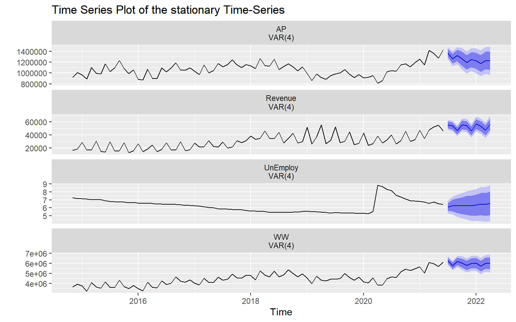

```r
fcst.plot <- autoplot(forecast(var2)) +
  ggtitle("Time Series Plot of the stationary Time-Series")
fcst.plot
```

Predictions for the next 12 months:

```r
pred <- predict(var2, n.ahead = 12)
pred
```

```
## $AP
##          fcst     lower   upper       CI
##  [1,] 1370917 1259261.0 1482573 111656.1
##  [2,] 1265490 1126882.6 1404097 138607.4
##  [3,] 1324515 1165187.0 1483844 159328.5
##  [4,] 1264740 1067999.5 1461480 196740.4
##  [5,] 1198216  993558.6 1402874 204657.8
##  [6,] 1250873 1037605.0 1464140 213267.7
##  [7,] 1225564  996578.7 1454550 228985.5
##  [8,] 1177415  938488.1 1416341 238926.6
##  [9,] 1231569  984128.8 1479010 247440.5
## [10,] 1226660  965475.9 1487843 261183.6
## [11,] 1185012  910871.9 1459153 274140.4
## [12,] 1238699  955323.9 1522074 283375.2
##
```

[output cut: 44 more lines]

## 6. Testing the model’s Granger causality, heteroscedasticity, normality, and stability

Note that I have already conducted a serial test, so I will skip that for now. First, I try and see if unemployment rate Granger causes the other variables:

```r
causality(var2, cause = "UnEmploy")$Granger
```

```
##
##  Granger causality H0: UnEmploy do not Granger-cause AP WW Revenue
##
## data:  VAR object var2
## F-Test = 2.5144, df1 = 12, df2 = 236, p-value = 0.003958
```

As shown, I can reject the null hypothesis, concluding that unemployment rate does Granger causes other variables.

Next, I check for heteroscedasticity:

```r
arch.test(var2, lags.multi = 10, multivariate.only = TRUE)
```

```
##
##  ARCH (multivariate)
##
## data:  Residuals of VAR object var2
## Chi-squared = 660, df = 1000, p-value = 1
```

Test succeeded.

Normality test:

```r
normality.test(var2, multivariate.only = TRUE)
```

```
## $JB
##
##  JB-Test (multivariate)
##
## data:  Residuals of VAR object var2
## Chi-squared = 3360.7, df = 8, p-value < 2.2e-16
##
##
## $Skewness
##
##  Skewness only (multivariate)
##
## data:  Residuals of VAR object var2
## Chi-squared = 286.57, df = 4, p-value < 2.2e-16
##
##
## $Kurtosis
##
##  Kurtosis only (multivariate)
##
## data:  Residuals of VAR object var2
## Chi-squared = 3074.1, df = 4, p-value < 2.2e-16
```

Failed, the model did not pass normality test for residuals.

Stability test:

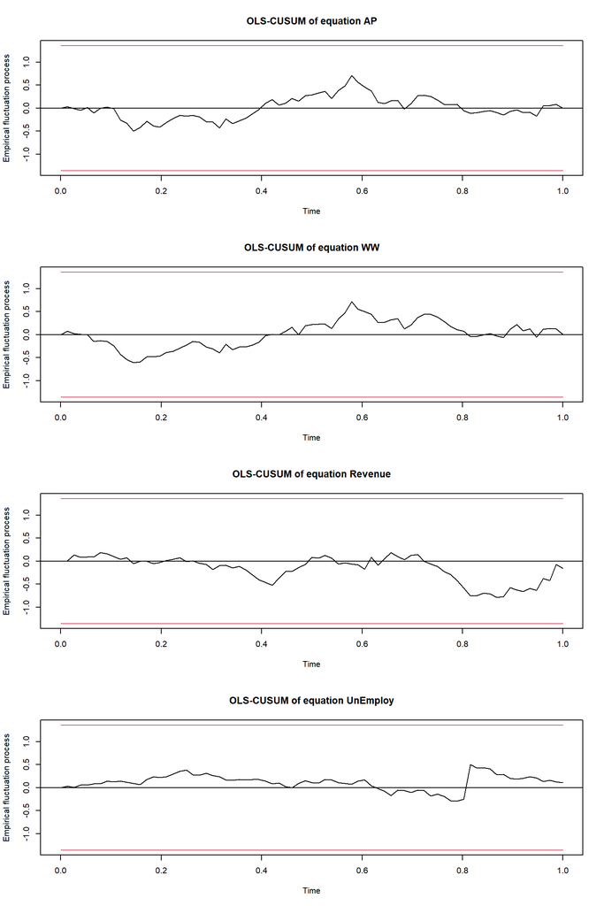

```r
stability(var2, type="OLS-CUSUM") %>% plot
```

Succeeded. The model is stable.